# #1 PBN Experiment steps for processing

21 junio 2024

### #1 Processing steps

#### Perform the simulation

For each flight simulation, “Flightapp” generates 3 tables:

- flight (position, speed, etc.)
- actions (control actions performed by the pilot)
- imquery (information checks performed by the pilot)

#### Discretize simulation tables

- For each flight, “PostFlight” generates 1 table (ending with “dis”), and we export as CSV for processing with R.
- All CSV flights need to be stored in a specific folder of the R path (“csv_in/”).

#### Create “big” dataset in R

Using the function “createInfoDF”, that returns a list of dataframes, we obtain the dataset with all flights and the initial variables. Useless rows are discarded in this step.

#### The “flights_info” table

We also obtain a dataframe with a summary of the dataset, we call it “flights_info”:

| id | disTable | initialRows | firstIndex | lastIndex | deviationfirstIndex | deviationlastIndex | deviationexceeded | deviationmax | deviationmean |
| --- | --- | --- | --- | --- | --- | --- | --- | --- | --- |
| 1 | 20240609162041dis | 2060 | 120 | 2031 | 0.0352506 | 0.0689405 | 10.72176 | 1.903232 | 0.4247290 |
| 2 | 20240609164752dis | 2012 | 104 | 1986 | 0.0199966 | 0.2739107 | 13.27669 | 2.385228 | 0.5489426 |
| 3 | 20240620201506dis | 2101 | 1 | 2021 | 0.0002836 | 0.0831241 | 33.44879 | 3.575805 | 0.8429628 |
| 4 | 20240620193702dis | 2036 | 1 | 1992 | 0.0005274 | 0.1977494 | 16.61647 | 3.297572 | 0.6056337 |

- For each one of the 4 flights, we see the total number of rows and the rows of interest (initialRows, firstIndex, lastIndex), which are kept.
- We also obtain basic statistics of the deviation:
- deviationfirstIndex & deviationlastIndex provide an indication that the flight is acceptable at the beginning and the end.
- deviationexceeded is the percentage of samples where the deviation is bigger than 1NM.
- deviationmax is the maximum deviation within the flight, and deviationmean is the mean.

#### Overview of the flights

This is a map representation of each flight:

##### Flight 1 :

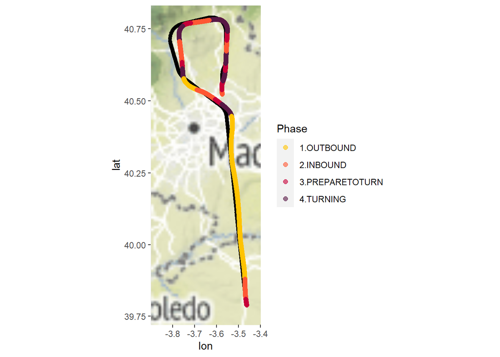

##### Flight 2 :

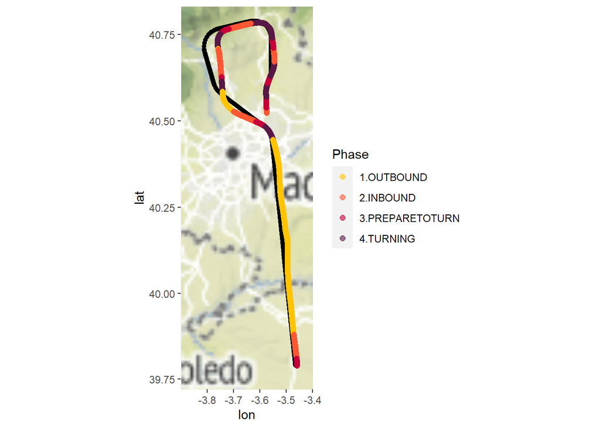

##### Flight 3 :

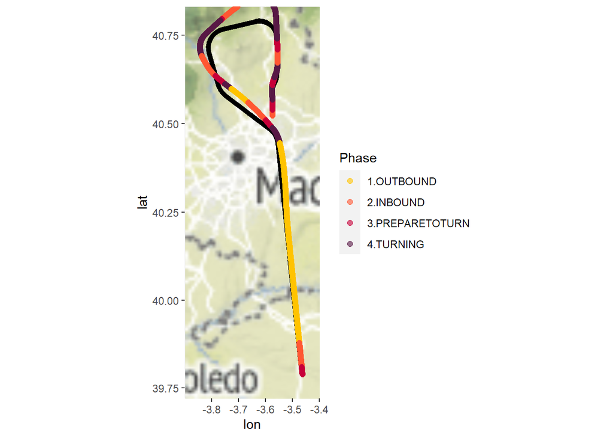

##### Flight 4 :

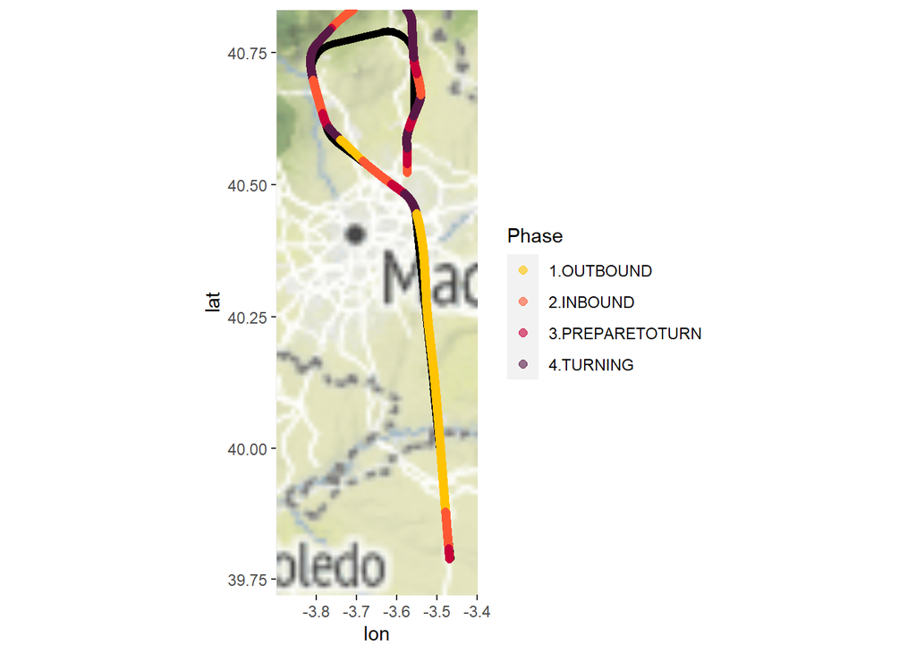